# TP 7 : Apprentissage supervisé et arbre de décision

- Montrer tout le code
- Cacher tout le code
- Voir les sources

Compléments de Mathématiques 2 - L3 MIASHS

Auteur·rice

HAMLIL Mohamed

Date de publication

17 mars 2026

# Préparation des données

## Chargement du jeu de données

```r
qualitative_vars  <- read.csv("../TP2/titanic_pre_processed_qualitative_vars.csv", stringsAsFactors = TRUE)
quantitative_vars <- read.csv("../TP2/titanic_pre_processed_quantitative_vars.csv")
target            <- read.csv("../TP2/titanic_pre_processed_target.csv")
target            <- as.factor(target$x)
```

Suppression des observations avec valeurs manquantes pour `Sex` (seulement 2 sur 876, soit < 0.2%) :

```r
isMissingSex <- which(is.na(qualitative_vars$Sex) | qualitative_vars$Sex == "")
if (length(isMissingSex) > 0) {
  qualitative_vars  <- qualitative_vars[-isMissingSex, ]
  quantitative_vars <- quantitative_vars[-isMissingSex, ]
  target            <- target[-isMissingSex]
}
```

## Vérification des types

```r
qualitative_vars$Pclass  <- as.factor(qualitative_vars$Pclass)
qualitative_vars$Sex     <- as.factor(qualitative_vars$Sex)
qualitative_vars$withFam <- as.factor(qualitative_vars$withFam)

str(qualitative_vars)
```

```
'data.frame':   874 obs. of  4 variables:
 $ Age_cat: Factor w/ 4 levels "Adolescent","Adulte",..: 2 2 2 2 2 NA 2 3 2 1 ...
 $ Pclass : Factor w/ 3 levels "1","2","3": 3 1 3 1 3 3 1 3 3 2 ...
 $ Sex    : Factor w/ 3 levels "","female","male": 3 2 2 2 3 3 3 3 2 2 ...
 $ withFam: Factor w/ 2 levels "0","1": 2 2 1 2 1 1 1 2 2 2 ...
```

```r
str(quantitative_vars)
```

```
'data.frame':   874 obs. of  5 variables:
 $ Age  : num  22 38 26 35 35 NA 54 2 27 14 ...
 $ SibSp: int  1 1 0 1 0 0 0 3 0 1 ...
 $ Parch: int  0 0 0 0 0 0 0 1 2 0 ...
 $ Fam  : int  1 1 0 1 0 0 0 4 2 1 ...
 $ Fare : num  7.25 71.28 7.92 53.1 8.05 ...
```

```r
str(target)
```

```
 Factor w/ 2 levels "Décédé","Survivant": 1 2 2 2 1 1 1 1 2 2 ...
```

# Arbre de décision

## Variables explicatives utilisées pour la prédiction

**NoteEncoding et normalisation**

Pour construire un arbre de décision, on n’a **pas besoin** de transformer les variables qualitatives (dummy coding ou label encoding) ni de normaliser/standardiser les variables quantitatives. L’arbre travaille avec des règles de division sur chaque variable individuellement, il gère nativement les variables qualitatives et quantitatives sur des échelles différentes.

On exclut `Fam`, `Parch` et `SibSp` puisqu’on utilisera `withFam` :

```r
predictive_vars <- data.frame(
  qualitative_vars[, c("Pclass", "Sex", "withFam")],
  Age  = quantitative_vars$Age,
  Fare = quantitative_vars$Fare
)
str(predictive_vars)
```

```
'data.frame':   874 obs. of  5 variables:
 $ Pclass : Factor w/ 3 levels "1","2","3": 3 1 3 1 3 3 1 3 3 2 ...
 $ Sex    : Factor w/ 3 levels "","female","male": 3 2 2 2 3 3 3 3 2 2 ...
 $ withFam: Factor w/ 2 levels "0","1": 2 2 1 2 1 1 1 2 2 2 ...
 $ Age    : num  22 38 26 35 35 NA 54 2 27 14 ...
 $ Fare   : num  7.25 71.28 7.92 53.1 8.05 ...
```

# Arbre de décision avec Holdout

## Partage du jeu de données

```r
set.seed(1234)
n <- nrow(predictive_vars)
inTrain <- sample(1:n, size = round(0.8 * n))

predictive_vars_train <- predictive_vars[inTrain, ]
predictive_vars_test  <- predictive_vars[-inTrain, ]
target_train          <- target[inTrain]
target_test           <- target[-inTrain]
```

## Gestion des données manquantes

On utilise la médiane imputation pour `Age`, en calculant la médiane sur le Train uniquement pour éviter le data leakage :

```r
library(caret)

Proc <- preProcess(predictive_vars_train, method = "medianImpute")
predictive_vars_train <- predict(Proc, predictive_vars_train)
predictive_vars_test  <- predict(Proc, predictive_vars_test)
```

## Phase d’apprentissage

```r
library(rpart)
library(rpart.plot)
```

La ligne ci-dessous entraîne un arbre de décision de classification (`method = "class"`) sur les données d’entraînement. La formule `target_train ~ .` signifie que l’on utilise toutes les variables de `predictive_vars_train` pour prédire `target_train`.

```r
classifTree <- rpart(target_train ~ ., data = predictive_vars_train,
                     method = "class")
```

**NoteCritère de division**

Par défaut, `rpart` utilise l’**indice de Gini** (impureté de Gini) pour choisir la meilleure règle de division à chaque noeud. On peut changer ce critère en utilisant l’argument `parms = list(split = "information")` pour utiliser l’**entropie** (gain d’information).

Visualisation de l’arbre :

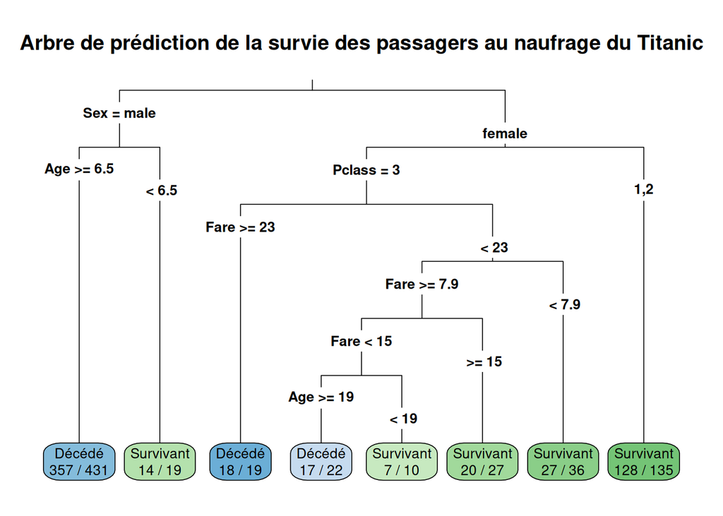

Figure 1: Arbre de décision (sans élagage)

```r
rpart.plot(x = classifTree, type = 3, extra = 2, fallen.leaves = TRUE,
           main = "Arbre de prédiction de la survie des passagers au naufrage du Titanic")
```

## Prédiction et évaluation sur le jeu de test

```r
target_pred <- predict(classifTree, predictive_vars_test, type = "class")

cm <- confusionMatrix(target_pred, target_test, positive = "Survivant")
cm
```

```
Confusion Matrix and Statistics

           Reference
Prediction  Décédé Survivant
  Décédé        99        22
  Survivant     12        42

               Accuracy : 0.8057
                 95% CI : (0.7392, 0.8615)
    No Information Rate : 0.6343
    P-Value [Acc > NIR] : 6.27e-07

                  Kappa : 0.5669

 Mcnemar's Test P-Value : 0.1227

            Sensitivity : 0.6562
            Specificity : 0.8919
         Pos Pred Value : 0.7778
         Neg Pred Value : 0.8182
             Prevalence : 0.3657
         Detection Rate : 0.2400
   Detection Prevalence : 0.3086
      Balanced Accuracy : 0.7741

       'Positive' Class : Survivant
```

```r
cat("Accuracy  :", round(cm$overall["Accuracy"], 4), "\n")
```

```
Accuracy  : 0.8057
```

```r
cat("Recall    :", round(cm$byClass["Sensitivity"], 4), "\n")
```

```
Recall    : 0.6562
```

```r
cat("Precision :", round(cm$byClass["Pos Pred Value"], 4), "\n")
```

```
Precision : 0.7778
```

## Élagage de l’arbre

La fonction `plotcp` affiche l’erreur de validation croisée (relative cross-validation error) en fonction du paramètre de complexité `cp`. Cela permet de choisir la bonne taille d’arbre pour éviter le surapprentissage.

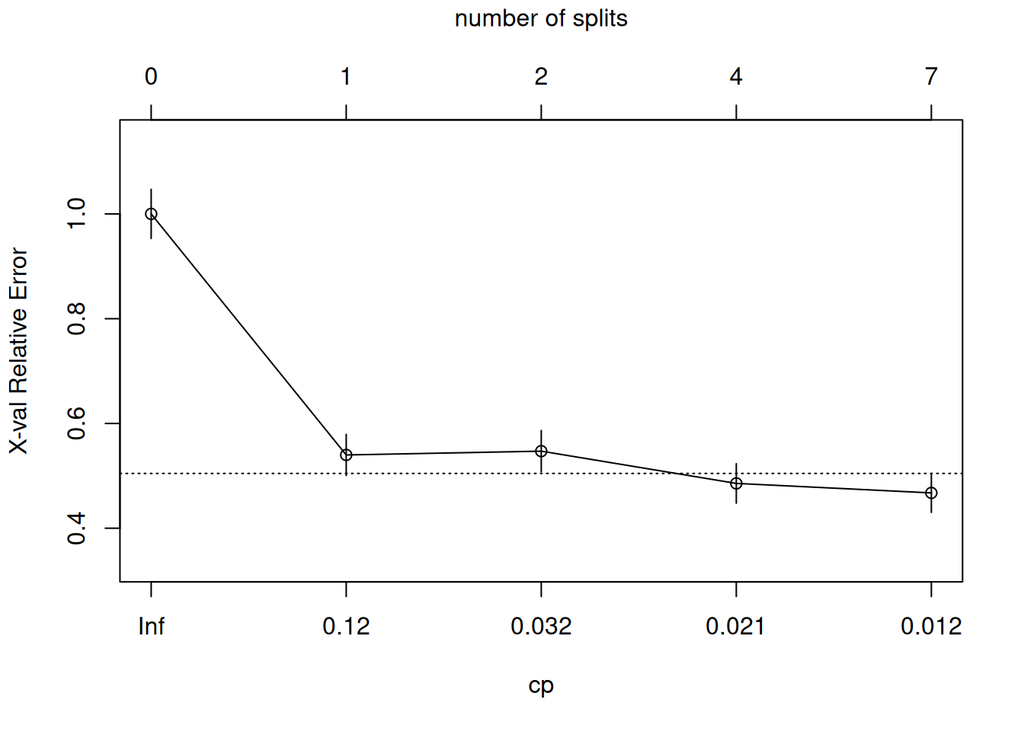

Figure 2: Erreur de CV relative en fonction du paramètre de complexité

```r
plotcp(classifTree, upper = "splits")
```

**AstuceChoix du cp optimal**

Selon la documentation, un bon choix est la valeur de `cp` correspondant à l’arbre le plus petit dont l’erreur de CV relative est **à moins d’un écart-type** du minimum (règle du “1-SE”). La ligne horizontale en pointillés sur le graphique correspond à `min(xerror) + xstd` au minimum.

```r
classifTree$cptable
```

```
          CP nsplit rel error    xerror       xstd
1 0.46014493      0 1.0000000 1.0000000 0.04682492
2 0.03260870      1 0.5398551 0.5398551 0.03923077
3 0.03079710      2 0.5072464 0.5471014 0.03942131
4 0.01449275      4 0.4456522 0.4855072 0.03770761
5 0.01000000      7 0.4021739 0.4673913 0.03716076
```

```r
xerror     <- classifTree$cptable[, "xerror"]
xstd       <- classifTree$cptable[, "xstd"]
cp         <- classifTree$cptable[, "CP"]
min.xerror <- which.min(xerror)

# Règle du 1-SE : plus petit arbre dont xerror < min(xerror) + xstd au minimum
threshold <- xerror[min.xerror] + xstd[min.xerror]
bestcp_idx <- min(which(xerror <= threshold))
bestcp     <- cp[bestcp_idx]

cat("Meilleur cp (règle 1-SE) :", bestcp, "\n")
```

```
Meilleur cp (règle 1-SE) : 0.01449275
```

```r
cat("Nombre de splits associé :", classifTree$cptable[bestcp_idx, "nsplit"], "\n")
```

```
Nombre de splits associé : 4
```

Élagage de l’arbre avec la valeur optimale du `cp` :

```r
prunedTree <- prune(classifTree, cp = bestcp)
```

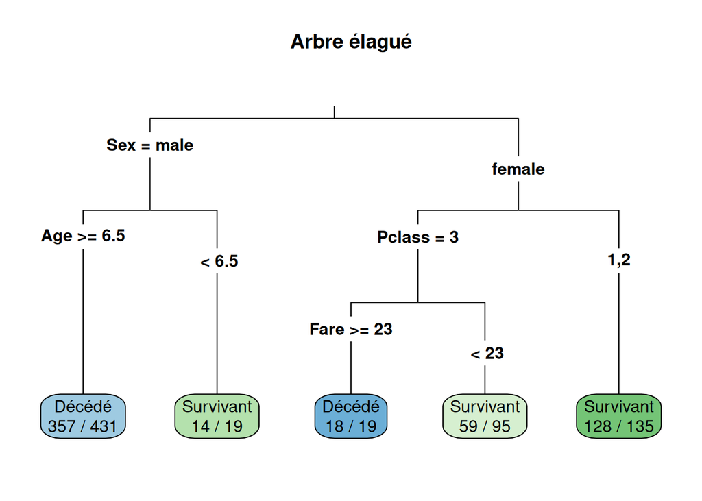

Figure 3: Arbre de décision élagué

```r
rpart.plot(prunedTree, type = 3, extra = 2, fallen.leaves = TRUE,
           main = "Arbre élagué")
```

## Prédiction avec l’arbre élagué

```r
target_pred_pruned <- predict(prunedTree, predictive_vars_test, type = "class")

cm_pruned <- confusionMatrix(target_pred_pruned, target_test, positive = "Survivant")
cm_pruned
```

```
Confusion Matrix and Statistics

           Reference
Prediction  Décédé Survivant
  Décédé        94        19
  Survivant     17        45

               Accuracy : 0.7943
                 95% CI : (0.7268, 0.8516)
    No Information Rate : 0.6343
    P-Value [Acc > NIR] : 3.434e-06

                  Kappa : 0.5536

 Mcnemar's Test P-Value : 0.8676

            Sensitivity : 0.7031
            Specificity : 0.8468
         Pos Pred Value : 0.7258
         Neg Pred Value : 0.8319
             Prevalence : 0.3657
         Detection Rate : 0.2571
   Detection Prevalence : 0.3543
      Balanced Accuracy : 0.7750

       'Positive' Class : Survivant
```

```r
cat("Accuracy  (élagué) :", round(cm_pruned$overall["Accuracy"], 4), "\n")
```

```
Accuracy  (élagué) : 0.7943
```

```r
cat("Recall    (élagué) :", round(cm_pruned$byClass["Sensitivity"], 4), "\n")
```

```
Recall    (élagué) : 0.7031
```

```r
cat("Precision (élagué) :", round(cm_pruned$byClass["Pos Pred Value"], 4), "\n")
```

```
Precision (élagué) : 0.7258
```

# Arbre de décision avec 10-fold cross-validation

## Sans élagage

```r
set.seed(1234)
nfolds <- 10
folds  <- sample(1:nfolds, n, replace = TRUE)
```

```r
accuracy_fold  <- numeric(nfolds)
recall_fold    <- numeric(nfolds)
precision_fold <- numeric(nfolds)

for (k in 1:nfolds) {
  inFold <- which(folds == k)

  predictive_vars_test  <- predictive_vars[inFold, ]
  target_test           <- target[inFold]
  predictive_vars_train <- predictive_vars[-inFold, ]
  target_train          <- target[-inFold]

  # Median imputation (sans data leakage)
  Proc <- preProcess(predictive_vars_train, method = "medianImpute")
  predictive_vars_train <- predict(Proc, predictive_vars_train)
  predictive_vars_test  <- predict(Proc, predictive_vars_test)

  # Apprentissage
  classifTree <- rpart(target_train ~ ., data = predictive_vars_train,
                       method = "class")

  # Prédiction
  target_pred <- predict(classifTree, predictive_vars_test, type = "class")

  # Métriques
  cm <- confusionMatrix(target_pred, target_test, positive = "Survivant")

  accuracy_fold[k]  <- cm$overall["Accuracy"]
  recall_fold[k]    <- cm$byClass["Sensitivity"]
  precision_fold[k] <- cm$byClass["Pos Pred Value"]
}

names(accuracy_fold)  <- paste0("fold_", 1:nfolds)
names(recall_fold)    <- paste0("fold_", 1:nfolds)
names(precision_fold) <- paste0("fold_", 1:nfolds)
```

```r
accuracy_fold
```

```
   fold_1    fold_2    fold_3    fold_4    fold_5    fold_6    fold_7    fold_8
0.8111111 0.7000000 0.8333333 0.7792208 0.7674419 0.7787611 0.8045977 0.8426966
   fold_9   fold_10
0.8289474 0.8750000
```

```r
recall_fold
```

```
   fold_1    fold_2    fold_3    fold_4    fold_5    fold_6    fold_7    fold_8
0.7187500 0.3750000 0.6250000 0.6571429 0.6315789 0.6481481 0.5757576 0.6875000
   fold_9   fold_10
0.7931034 0.7741935
```

```r
precision_fold
```

```
   fold_1    fold_2    fold_3    fold_4    fold_5    fold_6    fold_7    fold_8
0.7419355 0.5000000 0.8333333 0.8214286 0.8000000 0.8536585 0.8636364 0.8461538
   fold_9   fold_10
0.7666667 0.8888889
```

```r
cat("10-fold CV Mean Accuracy  :", round(mean(accuracy_fold), 4), "\n")
```

```
10-fold CV Mean Accuracy  : 0.8021
```

```r
cat("10-fold CV Mean Recall    :", round(mean(recall_fold), 4), "\n")
```

```
10-fold CV Mean Recall    : 0.6486
```

```r
cat("10-fold CV Mean Precision :", round(mean(precision_fold, na.rm = TRUE), 4), "\n")
```

```
10-fold CV Mean Precision : 0.7916
```

## Avec élagage

```r
accuracy_fold_p  <- numeric(nfolds)
recall_fold_p    <- numeric(nfolds)
precision_fold_p <- numeric(nfolds)

for (k in 1:nfolds) {
  inFold <- which(folds == k)

  predictive_vars_test  <- predictive_vars[inFold, ]
  target_test           <- target[inFold]
  predictive_vars_train <- predictive_vars[-inFold, ]
  target_train          <- target[-inFold]

  # Median imputation (sans data leakage)
  Proc <- preProcess(predictive_vars_train, method = "medianImpute")
  predictive_vars_train <- predict(Proc, predictive_vars_train)
  predictive_vars_test  <- predict(Proc, predictive_vars_test)

  # Apprentissage
  classifTree <- rpart(target_train ~ ., data = predictive_vars_train,
                       method = "class")

  # Élagage (règle du 1-SE)
  xerror     <- classifTree$cptable[, "xerror"]
  xstd       <- classifTree$cptable[, "xstd"]
  cp_vals    <- classifTree$cptable[, "CP"]
  min_idx    <- which.min(xerror)
  threshold  <- xerror[min_idx] + xstd[min_idx]
  best_idx   <- min(which(xerror <= threshold))
  best_cp    <- cp_vals[best_idx]

  prunedTree  <- prune(classifTree, cp = best_cp)

  # Prédiction avec l'arbre élagué
  target_pred <- predict(prunedTree, predictive_vars_test, type = "class")

  # Métriques
  cm <- confusionMatrix(target_pred, target_test, positive = "Survivant")

  accuracy_fold_p[k]  <- cm$overall["Accuracy"]
  recall_fold_p[k]    <- cm$byClass["Sensitivity"]
  precision_fold_p[k] <- cm$byClass["Pos Pred Value"]
}

names(accuracy_fold_p)  <- paste0("fold_", 1:nfolds)
names(recall_fold_p)    <- paste0("fold_", 1:nfolds)
names(precision_fold_p) <- paste0("fold_", 1:nfolds)
```

```r
accuracy_fold_p
```

```
   fold_1    fold_2    fold_3    fold_4    fold_5    fold_6    fold_7    fold_8
0.7666667 0.7000000 0.8020833 0.7792208 0.7674419 0.7876106 0.8045977 0.8202247
   fold_9   fold_10
0.7894737 0.8500000
```

```r
recall_fold_p
```

```
   fold_1    fold_2    fold_3    fold_4    fold_5    fold_6    fold_7    fold_8
0.7500000 0.4166667 0.6250000 0.6857143 0.6052632 0.6296296 0.7575758 0.7187500
   fold_9   fold_10
0.7586207 0.8064516
```

```r
precision_fold_p
```

```
   fold_1    fold_2    fold_3    fold_4    fold_5    fold_6    fold_7    fold_8
0.6486486 0.5000000 0.7407407 0.8000000 0.8214286 0.8947368 0.7352941 0.7666667
   fold_9   fold_10
0.7096774 0.8064516
```

```r
cat("10-fold CV Mean Accuracy  (élagué) :", round(mean(accuracy_fold_p), 4), "\n")
```

```
10-fold CV Mean Accuracy  (élagué) : 0.7867
```

```r
cat("10-fold CV Mean Recall    (élagué) :", round(mean(recall_fold_p), 4), "\n")
```

```
10-fold CV Mean Recall    (élagué) : 0.6754
```

```r
cat("10-fold CV Mean Precision (élagué) :", round(mean(precision_fold_p, na.rm = TRUE), 4), "\n")
```

```
10-fold CV Mean Precision (élagué) : 0.7424
```